# Small Group Collaboration - Session 7

November 5, 2020

## Data

These data come from the Gapminder Foundation, an organization interested in increasing the use and understanding of statistics and other information about social, economic and environmental development at local, national and global levels.

- Math Achievement – Average score in the international TIMSS test for children in the 8th grade
- Income – Gross domestic product per person adjusted for differences in purchasing power (in 2011 international dollars)

## Exploratory Visualization

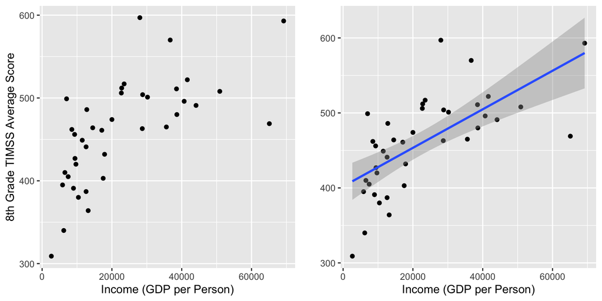

## Fitting a Linear Regression

```r
income_math_lm <- lm(grade_8_math_score ~ income, data = income_math)
get_regression_table(income_math_lm)
```

```
## # A tibble: 2 x 7
##   term      estimate std_error statistic p_value lower_ci upper_ci
##   <chr>        <dbl>     <dbl>     <dbl>   <dbl>    <dbl>    <dbl>
## 1 intercept  402.         13.2     30.4        0  375.     429.
## 2 income       0.003       0        5.44       0    0.002    0.004
```

- How would you interpret the coefficient on `income`?
- What does the `std_error` column represent?
- How is the `statistic` for `income` calculated?

## Model Conditions

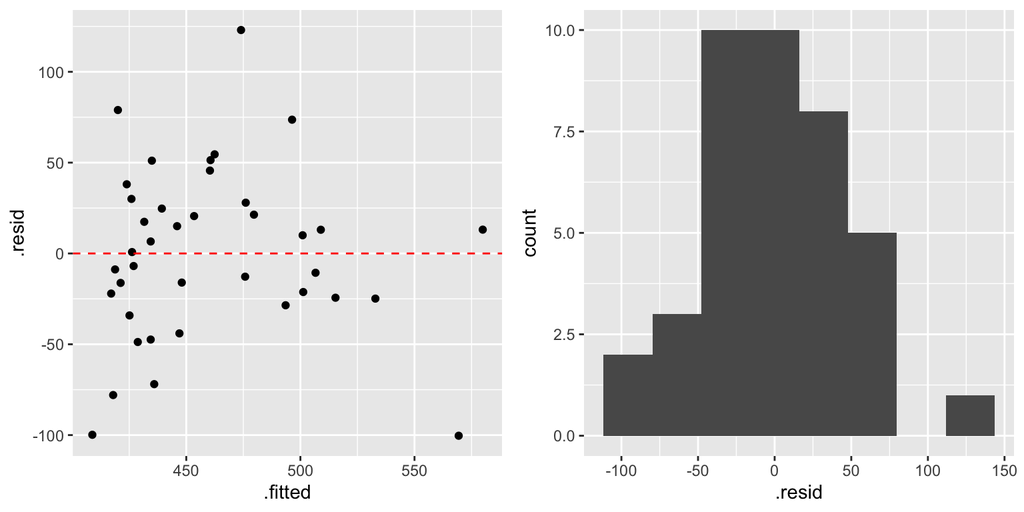

What decisions would you reach about the model conditions?

## Hypothesis Test

- What are the hypothesis for testing for a linear relationship between income and grade 8 math scores?
- What population parameter are we interested in making inference about?

## Permutation Distribution

- What steps would be used to create the null distribution below?

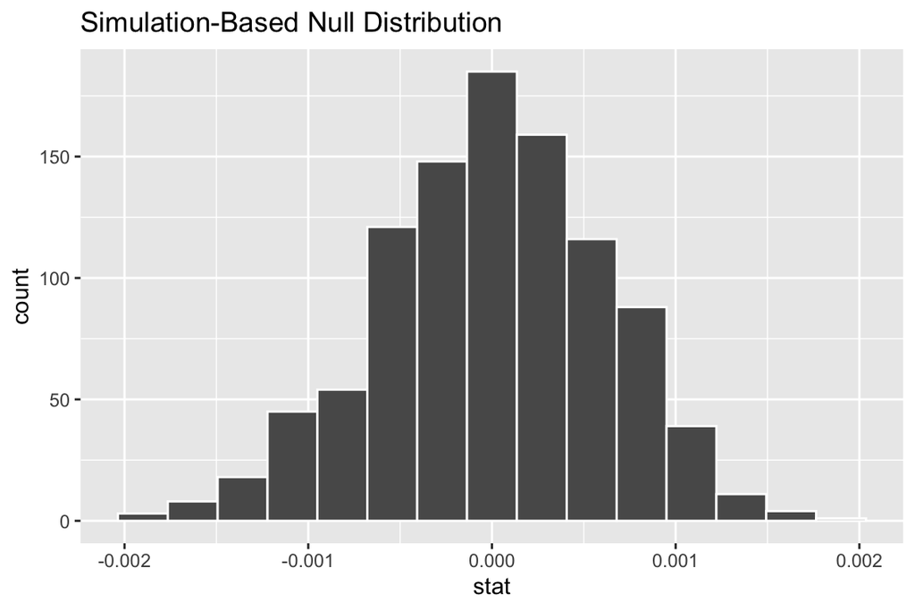

## Obtaining a p-value

- Given the distribution of permuted slopes, what information do you need to calculate the p-value for the hypothesis test?
- What \(\alpha\) would you choose for the test? Why?
- Given the p-value below, what decision would you make regarding your hypotheses?
- What would you conclude about the relationship?

```
## # A tibble: 1 x 1
##   p_value
##     <dbl>
## 1       0
```

## Interpretting a p-value

The p-value above gives the following warning:

`Warning message: Please be cautious in reporting a p-value of 0. This result is an approximation based on the number of reps chosen in the generate() step.`

- What does this mean?
- For a distribution that used 1,000 reps, how would you interpret a p-value of 0?
- How would you change this interpretation to use a probability statement instead?

## Confidence Intervals & p-values

Given the decision you reached for the hypothesis test, what range of values do you think are plausible for \(\beta_1\)? Why?

## Code Used in this Session

- Visualizations

```r
raw <- income_math %>%
  ggplot(aes(x = income, y = grade_8_math_score)) +
  geom_point() +
  labs(x = "Income (GDP per Person)",
       y = "8th Grade TIMSS Average Score")

smooth <- income_math %>%
  ggplot(aes(x = income, y = grade_8_math_score)) +
  geom_point() +
  geom_smooth(method = "lm") +
  labs(x = "Income (GDP per Person)",
       y = "")
```

## Model Conditions – Code

```r
line <- income_math_lm %>%
  ggplot(aes(x = .fitted, y = .resid)) +
  geom_point() +
  geom_hline(yintercept = 0,
             color = "red",
             linetype = "dashed")

norm <- income_math_lm  %>%
  ggplot(aes(x = .resid)) +
  geom_histogram(bins = 8)
```

## Null Distribution – Code

```r
null <- income_math %>%
  specify(grade_8_math_score ~ income) %>%
  hypothesise(null = "independence") %>%
  generate(reps = 1000, type = "permute") %>%
  calculate(stat = "slope")

null %>%
  visualize()
```

## p-value – Code

```r
obs_slope <- income_math %>%
  specify(grade_8_math_score ~ income) %>%
  calculate(stat = "slope")

get_p_value(null,
            obs_stat = obs_slope,
            direction = "two-sided")
```